# pedigree-hetero-count

Nurit Eliash

1/24/2022

### load libraries

```r
library("tidyverse")
library("plyr")
library("dplyr")
library("ggplot2")
library("scales")
library("ggpubr")
library("gridExtra")
library("grid")
library("GGally")
library("vcfR") # for extracting genotype data from a vcf file
library("data.table")
library("stringr")
library("janitor")
library("gmodels")
library("rstatix")
library("freqtables")
library("cowplot")
library("patchwork") # for gathering the plots
#library("ggthemes") # for more colors in the ggplot
knitr::opts_chunk$set(echo = TRUE, warning = FALSE, message = FALSE,
                     fig.width = 10,
                      fig.asp = 0.9,
                      out.width = "100%")
#fig.width = 6,fig.asp = 0.8,out.width = "100%"
```

## Load Variant Call Format (VCF) file.

```r
vcf <- read.vcfR("/Users/nuriteliash/Documents/GitHub/varroa-linkage-map/data/vcf_filter/Q40BIALLDP16HDP40mis.5Chr7/Q40BIALLDP16HDP40mis.5Chr7.recode.vcf", verbose = FALSE )
vcf
```

```
## ***** Object of Class vcfR *****
## 223 samples
## 7 CHROMs
## 35,169 variants
## Object size: 293.5 Mb
## 0 percent missing data
## *****        *****         *****
```

```r
# extract the genotype for each site in each individual
gt <- extract.gt(vcf, element = "GT")
gt <- as.data.frame(t(gt)) %>%
  rownames_to_column("ID")
#clean the ID names
gt$ID <- sub("_[^_]+$", "", gt$ID)

table <-  gt %>%
  t() %>%
  as.data.frame() %>%
  row_to_names(row_number = 1) %>%
  dplyr::select(contains(c("son", "dat", "fnd"))) # keep only adults of F0, F1 and F2

# set the families (include only families with at least one adult F2)
family = grep("grndat|grnson",gt$ID, value=TRUE) %>%
  str_extract("[^_]+")  %>%
  unique()

# or, include all F2 samples, but indicate if they have an adult sister (may indicate if the F1 female was fertilized)
#family = grep("grn",gt$ID, value=TRUE) %>%
#  str_extract("[^_]+")  %>%
#  unique()
```

# Crossing homozygotic male, with heterozygotic female

## (5) F1 male (0/0) x female (0/1)

### step-by-step filtering:

#### When do we lose most of the sites in the F2 mites?

We saw theres much difference in the number of sites in each cross.  
to check this issue,we checked which of the filters is reducing most of the sites

#### F2 genotypes, no filters

```r
# define a list to put all the data frames in
obs <- list()

for (fam in family) {

obs[[fam]] <- table %>%
  dplyr::select(starts_with(fam)) %>%
  #  dplyr::filter_at(vars(matches("_fnd")), all_vars(. == "0/0")) %>% # force F0 female to be homo, like her son
 # dplyr::filter_at(vars(matches("_son")), all_vars(. == "0/0")) %>%
  #dplyr::filter_at(vars(matches("_dat")), all_vars(. == "0/1")) %>%
  dplyr::select(contains("grn")) %>%
  tidyr::pivot_longer(everything())  %>%
  dplyr::rename(sample = name, gt = value) %>%
  dplyr::count(sample, gt, .drop = FALSE) %>%
  dplyr::filter(gt %in% c("0/0", "1/1", "0/1")) %>%
  mutate(n = as.numeric(n)) %>%
  group_by(sample) %>%
  mutate(total = as.numeric(sum(n))) %>%
  mutate(sex = case_when(
    grepl("son", sample) ~ "male",
    grepl("dat", sample) ~ "female"))
}

# bind all families together, to a final data frame containing all observed counts
observed <- do.call("rbind", obs) %>% mutate(sample = as.character(sample))
samples <- data.frame(sample = rep(unique(observed$sample), each =3), gt = rep(c("0/0", "0/1", "1/1")))

samples_obs <- left_join(samples, observed, by=c("sample","gt")) %>% mutate(sex = case_when(
    grepl("son", sample) ~ "male",
    grepl("dat", sample) ~ "female")) %>%
    group_by(sample) %>%
    replace(is.na(.), 0) %>%
    mutate(total = as.numeric(sum(n))) %>%
    dplyr::mutate(prop = n/total)

pooled_obs_count =  samples_obs %>%
    dplyr::filter(total>=10) %>%
    filter(gt =="0/0") %>%
    group_by(sex) %>%
    mutate(sites = sum(total)) %>%
   mutate(count_sample = n_distinct(sample)) %>%
   select(c(sex,sites,count_sample)) %>%
    unique()

pooled_obs_count
```

```
## # A tibble: 2 × 3
## # Groups:   sex [2]
##   sex     sites count_sample
##   <chr>   <dbl>        <int>
## 1 male   411271           26
## 2 female 518977           25
```

```r
p_all_f2_bar = samples_obs %>% dplyr::filter(total>=10) %>%
    ggplot(aes(fill=gt, y=prop, x=sex)) +
    geom_bar(position="fill", stat="identity", ) +
    labs(fill = "Genotype") +
    theme_classic() +
    theme(axis.text.x = element_text(size=12),
        axis.text.y = element_text(size=12)) +
     scale_fill_manual(values=c("#ffbf00", "#66b032","#1982c4"))+
    # theme(legend.position = "none")+
  ggtitle("No filter",
          subtitle = paste("F2 female = ", filter(pooled_obs_count, sex == 'female')$sites, ", male =", filter(pooled_obs_count, sex == 'male')$sites))
```

#### F0 female, (0/0)

```r
# define a list to put all the data frames in
obs <- list()

for (fam in family) {

obs[[fam]] <- table %>%
  dplyr::select(starts_with(fam)) %>%
    dplyr::filter_at(vars(matches("_fnd")), all_vars(. == "0/0")) %>% # force F0 female to be homo, like her son
 # dplyr::filter_at(vars(matches("_son")), all_vars(. == "0/0")) %>%
  #dplyr::filter_at(vars(matches("_dat")), all_vars(. == "0/1")) %>%
  dplyr::select(contains("grn")) %>%
  tidyr::pivot_longer(everything())  %>%
  dplyr::rename(sample = name, gt = value) %>%
  dplyr::count(sample, gt, .drop = FALSE) %>%
  dplyr::filter(gt %in% c("0/0", "1/1", "0/1")) %>%
  mutate(n = as.numeric(n)) %>%
  group_by(sample) %>%
  mutate(total = as.numeric(sum(n))) %>%
  mutate(sex = case_when(
    grepl("son", sample) ~ "male",
    grepl("dat", sample) ~ "female"))
}

# bind all families together, to a final data frame containing all observed counts
observed <- do.call("rbind", obs) %>% mutate(sample = as.character(sample))
samples <- data.frame(sample = rep(unique(observed$sample), each =3), gt = rep(c("0/0", "0/1", "1/1")))

samples_obs <- left_join(samples, observed, by=c("sample","gt")) %>% mutate(sex = case_when(
    grepl("son", sample) ~ "male",
    grepl("dat", sample) ~ "female")) %>%
    group_by(sample) %>%
    replace(is.na(.), 0) %>%
    mutate(total = as.numeric(sum(n))) %>%
    dplyr::mutate(prop = n/total)

pooled_obs_count =  samples_obs %>%
    dplyr::filter(total>=10) %>%
    filter(gt =="0/0") %>%
    group_by(sex) %>%
    mutate(sites = sum(total)) %>%
   mutate(count_sample = n_distinct(sample)) %>%
   select(c(sex,sites,count_sample)) %>%
    unique()

pooled_obs_count
```

```
## # A tibble: 2 × 3
## # Groups:   sex [2]
##   sex     sites count_sample
##   <chr>   <dbl>        <int>
## 1 male   106069           26
## 2 female 112657           25
```

```r
p_F0_bar = samples_obs %>% dplyr::filter(total>=10) %>%
    ggplot(aes(fill=gt, y=prop, x=sex)) +
    geom_bar(position="fill", stat="identity", ) +
    labs(fill = "Genotype") +
    theme_classic() +
    theme(axis.text.x = element_text(size=12),
        axis.text.y = element_text(size=12)) +
     scale_fill_manual(values=c("#ffbf00", "#66b032","#1982c4"))+
     theme(legend.position = "none")+
  ggtitle("F0 female (0/0)",
          subtitle = paste("F2 female = ", filter(pooled_obs_count, sex == 'female')$sites, ", male =", filter(pooled_obs_count, sex == 'male')$sites))
```

#### F0 female, (0/0); F1 male (0/0)

```r
# define a list to put all the data frames in
obs <- list()

for (fam in family) {

obs[[fam]] <- table %>%
  dplyr::select(starts_with(fam)) %>%
    dplyr::filter_at(vars(matches("_fnd")), all_vars(. == "0/0")) %>% # force F0 female to be homo, like her son
  dplyr::filter_at(vars(matches("_son")), all_vars(. == "0/0")) %>%
  #dplyr::filter_at(vars(matches("_dat")), all_vars(. == "0/1")) %>%
  dplyr::select(contains("grn")) %>%
  tidyr::pivot_longer(everything())  %>%
  dplyr::rename(sample = name, gt = value) %>%
  dplyr::count(sample, gt, .drop = FALSE) %>%
  dplyr::filter(gt %in% c("0/0", "1/1", "0/1")) %>%
  mutate(n = as.numeric(n)) %>%
  group_by(sample) %>%
  mutate(total = as.numeric(sum(n))) %>%
  mutate(sex = case_when(
    grepl("son", sample) ~ "male",
    grepl("dat", sample) ~ "female"))
}

# bind all families together, to a final data frame containing all observed counts
observed <- do.call("rbind", obs) %>% mutate(sample = as.character(sample))
samples <- data.frame(sample = rep(unique(observed$sample), each =3), gt = rep(c("0/0", "0/1", "1/1")))

samples_obs <- left_join(samples, observed, by=c("sample","gt")) %>% mutate(sex = case_when(
    grepl("son", sample) ~ "male",
    grepl("dat", sample) ~ "female")) %>%
    group_by(sample) %>%
    replace(is.na(.), 0) %>%
    mutate(total = as.numeric(sum(n))) %>%
    dplyr::mutate(prop = n/total)

pooled_obs_count =  samples_obs %>%
    dplyr::filter(total>=10) %>%
    filter(gt =="0/0") %>%
    group_by(sex) %>%
    mutate(sites = sum(total)) %>%
   mutate(count_sample = n_distinct(sample)) %>%
   select(c(sex,sites,count_sample)) %>%
    unique()

pooled_obs_count
```

```
## # A tibble: 2 × 3
## # Groups:   sex [2]
##   sex    sites count_sample
##   <chr>  <dbl>        <int>
## 1 male   66200           26
## 2 female 67468           25
```

```r
p_F0_F1_male_bar = samples_obs %>% dplyr::filter(total>=10) %>%
    ggplot(aes(fill=gt, y=prop, x=sex)) +
    geom_bar(position="fill", stat="identity", ) +
    labs(fill = "Genotype") +
    theme_classic() +
    theme(axis.text.x = element_text(size=12),
        axis.text.y = element_text(size=12)) +
     scale_fill_manual(values=c("#ffbf00", "#66b032","#1982c4"))+
     theme(legend.position = "none")+
  ggtitle("F0 female (0/0), F1 male (0/0)",
          subtitle = paste("F2 female = ", filter(pooled_obs_count, sex == 'female')$sites, ", male =", filter(pooled_obs_count, sex == 'male')$sites))
```

#### F0 female, (0/0); F1 female (0/1)

```r
# define a list to put all the data frames in
obs <- list()

for (fam in family) {

obs[[fam]] <- table %>%
  dplyr::select(starts_with(fam)) %>%
    dplyr::filter_at(vars(matches("_fnd")), all_vars(. == "0/0")) %>% # force F0 female to be homo, like her son
  #dplyr::filter_at(vars(matches("_son")), all_vars(. == "0/0")) %>%
  dplyr::filter_at(vars(matches("_dat")), all_vars(. == "0/1")) %>%
  dplyr::select(contains("grn")) %>%
  tidyr::pivot_longer(everything())  %>%
  dplyr::rename(sample = name, gt = value) %>%
  dplyr::count(sample, gt, .drop = FALSE) %>%
  dplyr::filter(gt %in% c("0/0", "1/1", "0/1")) %>%
  mutate(n = as.numeric(n)) %>%
  group_by(sample) %>%
  mutate(total = as.numeric(sum(n))) %>%
  mutate(sex = case_when(
    grepl("son", sample) ~ "male",
    grepl("dat", sample) ~ "female"))
}

# bind all families together, to a final data frame containing all observed counts
observed <- do.call("rbind", obs) %>% mutate(sample = as.character(sample))
samples <- data.frame(sample = rep(unique(observed$sample), each =3), gt = rep(c("0/0", "0/1", "1/1")))

samples_obs <- left_join(samples, observed, by=c("sample","gt")) %>% mutate(sex = case_when(
    grepl("son", sample) ~ "male",
    grepl("dat", sample) ~ "female")) %>%
    group_by(sample) %>%
    replace(is.na(.), 0) %>%
    mutate(total = as.numeric(sum(n))) %>%
    dplyr::mutate(prop = n/total)

pooled_obs_count =  samples_obs %>%
    dplyr::filter(total>=10) %>%
    filter(gt =="0/0") %>%
    group_by(sex) %>%
    mutate(sites = sum(total)) %>%
   mutate(count_sample = n_distinct(sample)) %>%
   select(c(sex,sites,count_sample)) %>%
    unique()

pooled_obs_count
```

```
## # A tibble: 2 × 3
## # Groups:   sex [2]
##   sex    sites count_sample
##   <chr>  <dbl>        <int>
## 1 male    9581           24
## 2 female 10087           25
```

```r
p_F0_F1_fem_bar = samples_obs %>% dplyr::filter(total>=10) %>%
    ggplot(aes(fill=gt, y=prop, x=sex)) +
    geom_bar(position="fill", stat="identity", ) +
    labs(fill = "Genotype") +
    theme_classic() +
    theme(axis.text.x = element_text(size=12),
        axis.text.y = element_text(size=12)) +
     scale_fill_manual(values=c("#ffbf00", "#66b032","#1982c4"))+
     theme(legend.position = "none")+
  ggtitle("F0 female (0/0), F1 female (0/1)",
          subtitle = paste("F2 female = ", filter(pooled_obs_count, sex == 'female')$sites, ", male =", filter(pooled_obs_count, sex == 'male')$sites))
```

#### F0 female, (0/0); F1 male (0/0); F1 female (0/1)

```r
# define a list to put all the data frames in
obs <- list()

for (fam in family) {

obs[[fam]] <- table %>%
  dplyr::select(starts_with(fam)) %>%
    dplyr::filter_at(vars(matches("_fnd")), all_vars(. == "0/0")) %>% # force F0 female to be homo, like her son
  dplyr::filter_at(vars(matches("_son")), all_vars(. == "0/0")) %>%
  dplyr::filter_at(vars(matches("_dat")), all_vars(. == "0/1")) %>%
  dplyr::select(contains("grn")) %>%
  tidyr::pivot_longer(everything())  %>%
  dplyr::rename(sample = name, gt = value) %>%
  dplyr::count(sample, gt, .drop = FALSE) %>%
  dplyr::filter(gt %in% c("0/0", "1/1", "0/1")) %>%
  mutate(n = as.numeric(n)) %>%
  group_by(sample) %>%
  mutate(total = as.numeric(sum(n))) %>%
  mutate(sex = case_when(
    grepl("son", sample) ~ "male",
    grepl("dat", sample) ~ "female"))
}

# bind all families together, to a final data frame containing all observed counts
observed <- do.call("rbind", obs) %>% mutate(sample = as.character(sample))
samples <- data.frame(sample = rep(unique(observed$sample), each =3), gt = rep(c("0/0", "0/1", "1/1")))

samples_obs <- left_join(samples, observed, by=c("sample","gt")) %>% mutate(sex = case_when(
    grepl("son", sample) ~ "male",
    grepl("dat", sample) ~ "female")) %>%
    group_by(sample) %>%
    replace(is.na(.), 0) %>%
    mutate(total = as.numeric(sum(n))) %>%
    dplyr::mutate(prop = n/total)

pooled_obs_count =  samples_obs %>%
    dplyr::filter(total>=10) %>%
    filter(gt =="0/0") %>%
    group_by(sex) %>%
    mutate(sites = sum(total)) %>%
   mutate(count_sample = n_distinct(sample)) %>%
   select(c(sex,sites,count_sample)) %>%
    unique()

pooled_obs_count
```

```
## # A tibble: 2 × 3
## # Groups:   sex [2]
##   sex    sites count_sample
##   <chr>  <dbl>        <int>
## 1 male    6001           19
## 2 female  5243           19
```

```r
p_00_01_bar = samples_obs %>% dplyr::filter(total>=10) %>%
    ggplot(aes(fill=gt, y=prop, x=sex)) +
    geom_bar(position="fill", stat="identity", ) +
    labs(fill = "Genotype") +
    theme_classic() +
    theme(axis.text.x = element_text(size=12),
        axis.text.y = element_text(size=12)) +
     scale_fill_manual(values=c("#ffbf00", "#66b032","#1982c4"))+
     theme(legend.position = "none")+
  ggtitle("F0 female (0/0), F1 male (0/0), F1 female (0/1)",
          subtitle = paste("F2 female = ", filter(pooled_obs_count, sex == 'female')$sites, ", male =", filter(pooled_obs_count, sex == 'male')$sites))

#density plot:
#samples_obs %>%
 # dplyr::filter(total>=10) %>%
 # dplyr::filter(sex == "male") %>%
 # dplyr::filter(gt == "0/1") %>%
  #ggplot(aes(prop, fill = sex)) + geom_density(colour = "black", alpha = 0.5) + theme_light() +
  #ggtitle("F2 maternal genotype proportion",
   #       subtitle = "F0 female (0/0); F1 male (0/0); F1 female (0/1)")

# histogram plot (count)
p_00_01_hist = samples_obs %>%
  dplyr::filter(total>=10) %>%
  dplyr::filter(gt == "0/1") %>%
  ggplot(aes(prop, fill = sex)) +
    geom_histogram(binwidth=.05, alpha=.7, position="identity") + theme_light() +
  ggtitle("F1 cross: male (0/0) x female (0/1)",
          subtitle = paste("F2 female = ", filter(pooled_obs_count, sex == 'female')$count_sample, ", male =", filter(pooled_obs_count, sex == 'male')$count_sample))
```

step-by-step filtering shows that the filtering of the F1 as 0/1 reduces most of the sites.  
This makes sense, and in corresponding with the varroa pedigree structure:

- when F0 female is 0/0, for her daughter to be 0/1, the F0 male should be either 0/1, or 1/1 Both genotypes are mote rare then 0/0.  
  therefore, when we ask for: F0 = 0/0, and F1 female = 0/1, we lose most of the sites.

This explains why we get such a high difference in the number of sites in F2 between the different crosses.

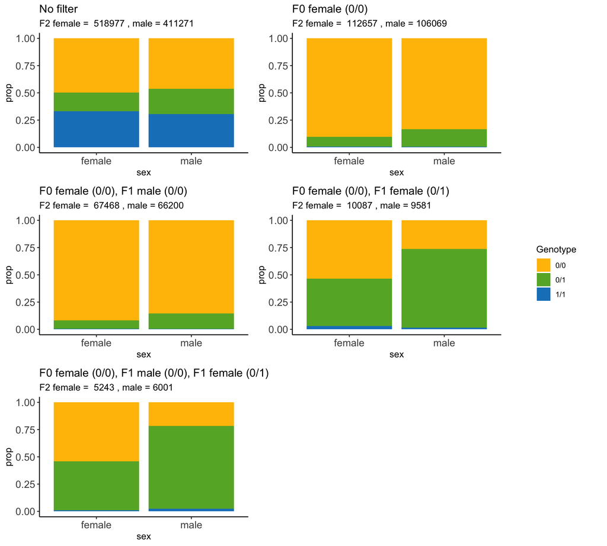

```r
legend <- get_legend(p_all_f2_bar)

# here the plots in a grid
prow <- plot_grid(p_all_f2_bar + theme(legend.position="none"),
           p_F0_bar + theme(legend.position="none")+ scale_y_continuous(),
           p_F0_F1_male_bar + theme(legend.position="none")+ scale_y_continuous(),
          p_F0_F1_fem_bar + theme(legend.position="none")+ scale_y_continuous(),
            p_00_01_bar + theme(legend.position="none")+ scale_y_continuous(),
          align = 'v',
           hjust = 1,
            vjust = 1.5,
           nrow = 3)

# here you add the legend
plot_grid( prow, legend, rel_widths = c(1, .2))
```

#### F0 female, (1/1); F1 male (1/1); F1 female (0/1)

```r
# define a list to put all the data frames in
obs <- list()

for (fam in family) {

obs[[fam]] <- table %>%
  dplyr::select(starts_with(fam)) %>%
    dplyr::filter_at(vars(matches("_fnd")), all_vars(. == "1/1")) %>% # force F0 female to be homo, like her son
  dplyr::filter_at(vars(matches("_son")), all_vars(. == "1/1")) %>%
  dplyr::filter_at(vars(matches("_dat")), all_vars(. == "0/1")) %>%
  dplyr::select(contains("grn")) %>%
  tidyr::pivot_longer(everything())  %>%
  dplyr::rename(sample = name, gt = value) %>%
  dplyr::count(sample, gt, .drop = FALSE) %>%
  dplyr::filter(gt %in% c("0/0", "1/1", "0/1")) %>%
  mutate(n = as.numeric(n)) %>%
  group_by(sample) %>%
  mutate(total = as.numeric(sum(n))) %>%
  mutate(sex = case_when(
    grepl("son", sample) ~ "male",
    grepl("dat", sample) ~ "female"))
}

# bind all families together, to a final data frame containing all observed counts
observed <- do.call("rbind", obs) %>% mutate(sample = as.character(sample))
samples <- data.frame(sample = rep(unique(observed$sample), each =3), gt = rep(c("0/0", "0/1", "1/1")))

samples_obs <- left_join(samples, observed, by=c("sample","gt")) %>% mutate(sex = case_when(
    grepl("son", sample) ~ "male",
    grepl("dat", sample) ~ "female")) %>%
    group_by(sample) %>%
    replace(is.na(.), 0) %>%
    mutate(total = as.numeric(sum(n))) %>%
    dplyr::mutate(prop = n/total)

pooled_obs_count =  samples_obs %>%
    dplyr::filter(total>=10) %>%
    filter(gt =="0/0") %>%
    group_by(sex) %>%
    mutate(sites = sum(total)) %>%
   mutate(count_sample = n_distinct(sample)) %>%
   select(c(sex,sites,count_sample)) %>%
    unique()

pooled_obs_count
```

```
## # A tibble: 2 × 3
## # Groups:   sex [2]
##   sex    sites count_sample
##   <chr>  <dbl>        <int>
## 1 male    6116           17
## 2 female  5410           15
```

```r
p_11_01_bar = samples_obs %>% dplyr::filter(total>=10) %>%
    ggplot(aes(fill=gt, y=prop, x=sex)) +
    geom_bar(position="fill", stat="identity", ) +
    labs(fill = "Genotype") +
    theme_classic() +
    theme(axis.text.x = element_text(size=12),
        axis.text.y = element_text(size=12)) +
     scale_fill_manual(values=c("#ffbf00", "#66b032","#1982c4"))+
     theme(legend.position = "none")+
  ggtitle("F0 female, (1/1); F1 male (1/1); F1 female (0/1)")

# histogram plot (count)
p_11_01_hist = samples_obs %>%
  dplyr::filter(total>=10) %>%
  dplyr::filter(gt == "0/1") %>%
  ggplot(aes(prop, fill = sex)) +
    geom_histogram(binwidth=.05, alpha=.7, position="identity") + theme_light() +
  ggtitle("F1 cross: male (1/1) x female (0/1)",
          subtitle = paste("F2 female = ", filter(pooled_obs_count, sex == 'female')$count_sample, ", male =", filter(pooled_obs_count, sex == 'male')$count_sample))
```

#### F0 female, (0/1); F1 male (0/1); F1 female (0/0)

```r
# define a list to put all the data frames in
obs <- list()

for (fam in family) {

obs[[fam]] <- table %>%
  dplyr::select(starts_with(fam)) %>%
    dplyr::filter_at(vars(matches("_fnd")), all_vars(. == "0/1")) %>% # force F0 female to be homo, like her son
  dplyr::filter_at(vars(matches("_son")), all_vars(. == "0/1")) %>%
  dplyr::filter_at(vars(matches("_dat")), all_vars(. == "0/0")) %>%
  dplyr::select(contains("grn")) %>%
  tidyr::pivot_longer(everything())  %>%
  dplyr::rename(sample = name, gt = value) %>%
  dplyr::count(sample, gt, .drop = FALSE) %>%
  dplyr::filter(gt %in% c("0/0", "1/1", "0/1")) %>%
  mutate(n = as.numeric(n)) %>%
  group_by(sample) %>%
  mutate(total = as.numeric(sum(n))) %>%
  mutate(sex = case_when(
    grepl("son", sample) ~ "male",
    grepl("dat", sample) ~ "female"))
}

# bind all families together, to a final data frame containing all observed counts
observed <- do.call("rbind", obs) %>% mutate(sample = as.character(sample))
samples <- data.frame(sample = rep(unique(observed$sample), each =3), gt = rep(c("0/0", "0/1", "1/1")))

samples_obs <- left_join(samples, observed, by=c("sample","gt")) %>% mutate(sex = case_when(
    grepl("son", sample) ~ "male",
    grepl("dat", sample) ~ "female")) %>%
    group_by(sample) %>%
    replace(is.na(.), 0) %>%
    mutate(total = as.numeric(sum(n))) %>%
    dplyr::mutate(prop = n/total)

pooled_obs_count =  samples_obs %>%
    dplyr::filter(total>=10) %>%
    filter(gt =="0/0") %>%
    group_by(sex) %>%
    mutate(sites = sum(total)) %>%
   mutate(count_sample = n_distinct(sample)) %>%
   select(c(sex,sites,count_sample)) %>%
    unique()

pooled_obs_count
```

```
## # A tibble: 2 × 3
## # Groups:   sex [2]
##   sex    sites count_sample
##   <chr>  <dbl>        <int>
## 1 male    2339           21
## 2 female  2811           19
```

```r
p_01_00_bar = samples_obs %>% dplyr::filter(total>=10) %>%
    ggplot(aes(fill=gt, y=prop, x=sex)) +
    geom_bar(position="fill", stat="identity", ) +
    labs(fill = "Genotype") +
    theme_classic() +
    theme(axis.text.x = element_text(size=12),
        axis.text.y = element_text(size=12)) +
     scale_fill_manual(values=c("#ffbf00", "#66b032","#1982c4"))+
     theme(legend.position = "none")+
  ggtitle("F0 female, (0/1); F1 male (0/1); F1 female (0/0)")

# histogram plot (count)
p_01_00_hist = samples_obs %>%
  dplyr::filter(total>=10) %>%
  dplyr::filter(gt == "0/0") %>%
  ggplot(aes(prop, fill = sex)) +
    geom_histogram(binwidth=.05, alpha=.7, position="identity") + theme_light() +
  ggtitle("F1 cross: male (0/1) x female (0/0)",
          subtitle = paste("F2 female = ", filter(pooled_obs_count, sex == 'female')$count_sample, ", male =", filter(pooled_obs_count, sex == 'male')$count_sample))
```

#### F0 female, (0/1); F1 male (0/1); F1 female (1/1)

```r
# define a list to put all the data frames in
obs <- list()

for (fam in family) {

obs[[fam]] <- table %>%
  dplyr::select(starts_with(fam)) %>%
    dplyr::filter_at(vars(matches("_fnd")), all_vars(. == "0/1")) %>% # force F0 female to be homo, like her son
  dplyr::filter_at(vars(matches("_son")), all_vars(. == "0/1")) %>%
  dplyr::filter_at(vars(matches("_dat")), all_vars(. == "1/1")) %>%
  dplyr::select(contains("grn")) %>%
  tidyr::pivot_longer(everything())  %>%
  dplyr::rename(sample = name, gt = value) %>%
  dplyr::count(sample, gt, .drop = FALSE) %>%
  dplyr::filter(gt %in% c("0/0", "1/1", "0/1")) %>%
  mutate(n = as.numeric(n)) %>%
  group_by(sample) %>%
  mutate(total = as.numeric(sum(n))) %>%
  mutate(sex = case_when(
    grepl("son", sample) ~ "male",
    grepl("dat", sample) ~ "female"))
}

# bind all families together, to a final data frame containing all observed counts
observed <- do.call("rbind", obs) %>% mutate(sample = as.character(sample))
samples <- data.frame(sample = rep(unique(observed$sample), each =3), gt = rep(c("0/0", "0/1", "1/1")))

samples_obs <- left_join(samples, observed, by=c("sample","gt")) %>% mutate(sex = case_when(
    grepl("son", sample) ~ "male",
    grepl("dat", sample) ~ "female")) %>%
    group_by(sample) %>%
    replace(is.na(.), 0) %>%
    mutate(total = as.numeric(sum(n))) %>%
    dplyr::mutate(prop = n/total)

pooled_obs_count =  samples_obs %>%
    dplyr::filter(total>=10) %>%
    filter(gt =="0/0") %>%
    group_by(sex) %>%
    mutate(sites = sum(total)) %>%
   mutate(count_sample = n_distinct(sample)) %>%
   select(c(sex,sites,count_sample)) %>%
    unique()

pooled_obs_count
```

```
## # A tibble: 2 × 3
## # Groups:   sex [2]
##   sex    sites count_sample
##   <chr>  <dbl>        <int>
## 1 male    1611           16
## 2 female  2415           14
```

```r
p_01_11_bar = samples_obs %>% dplyr::filter(total>=10) %>%
    ggplot(aes(fill=gt, y=prop, x=sex)) +
    geom_bar(position="fill", stat="identity", ) +
    labs(fill = "Genotype") +
    theme_classic() +
    theme(axis.text.x = element_text(size=12),
        axis.text.y = element_text(size=12)) +
     scale_fill_manual(values=c("#ffbf00", "#66b032","#1982c4"))+
     theme(legend.position = "none")+
  ggtitle("F0 female, (0/1); F1 male (0/1); F1 female (1/1)")

# histogram plot (count)
p_01_11_hist = samples_obs %>%
  dplyr::filter(total>=10) %>%
  dplyr::filter(gt == "1/1") %>%
  ggplot(aes(prop, fill = sex)) +
    geom_histogram(binwidth=.05, alpha=.7, position="identity") + theme_light() +
  ggtitle("F1 cross: male (0/1) x female (1/1)",
          subtitle = paste("F2 female = ", filter(pooled_obs_count, sex == 'female')$count_sample, ", male =", filter(pooled_obs_count, sex == 'male')$count_sample))
```

## can we see two seperate populations of F2 males? based on their genotype

- we plot the distribution of F2 males, based on the proportion of sites that behave automicticly (that is, have the same genotype as their mother (F1 female)).

Do we see two peeks? (that is, can we objectively detect 2 separate populations?

- If yes –  
  we can pick the % threshold that separate the 2 populations, and call them “normal” and “abnormal”.
- If no –  
  We need to keep all males, and filter by site.

#### Proportion of maternal genotype proportion in F2 mites

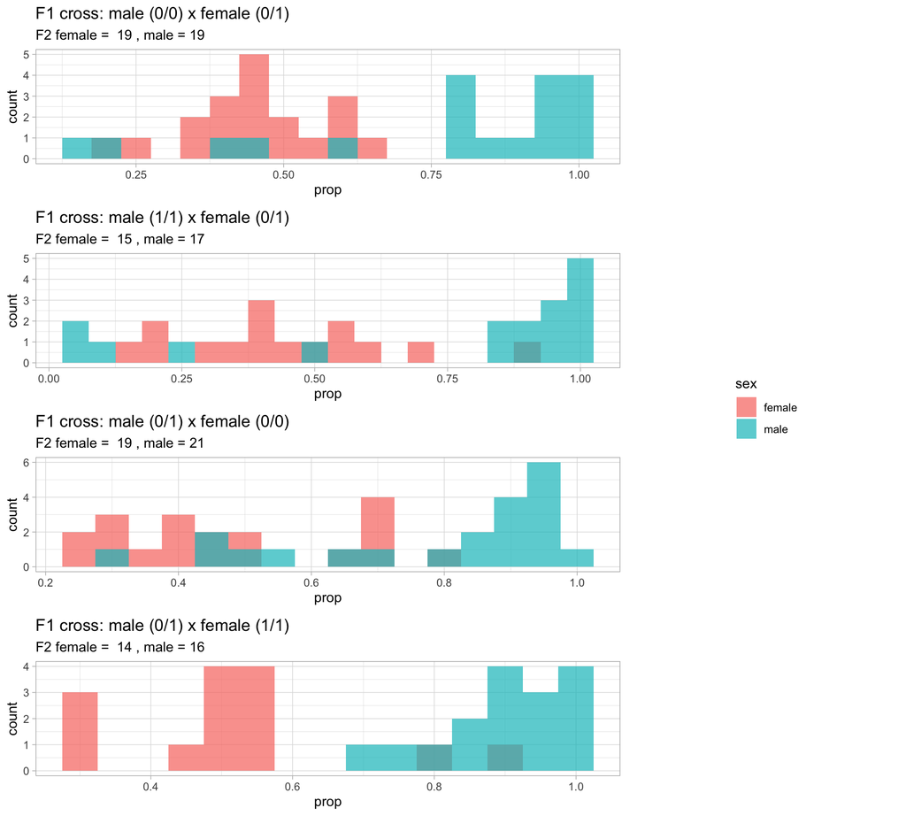

```r
legend <- get_legend(p_01_11_hist)   # get the legend of the first one plot

# now add the title
#title <- ggdraw() +
 # draw_label("Maternal genotype proportion in F2 mites", x = 0, y = 3) +
  #theme(plot.margin = margin(0, 0, 0, 7))

prow <- plot_grid(p_00_01_hist + theme(legend.position="none")+scale_x_continuous(n.breaks = 5),
           # here you add the percentage
           p_11_01_hist + theme(legend.position="none")+ scale_x_continuous(n.breaks = 5),
           p_01_00_hist + theme(legend.position="none")+ scale_x_continuous(n.breaks = 5),
          p_01_11_hist + theme(legend.position="none")+ scale_x_continuous(n.breaks = 5),
         align = 'v',
           hjust = -1,
           nrow = 4)

# here you add the legend
plot_grid( prow, legend, rel_widths = c(0.9, 0.4))
```

another option: pool all sites together